# BFS R package

Search and download data from the Federal Statistical Office

Félix Luginbühl

## Plan

1. A use case example.
2. Motivations behind the BFS package
3. Exploring the data catalog with BFS
4. All you need is `bfs_get_data()`

… and your questions

## 1. A use case example

- Swiss City Statistics app (https://city.felixluginbuhl.com/)

[figure not shown]

# 2. Motivations behind the BFS package

## Motivations behind the BFS package

- leveraging the full R ecosystem: R Shiny, Rmarkdown, etc.
- Data reproducibility and transparency
- Speed: get BFS data with 1 line of code

# 3. Exploring the data catalog with BFS

## Exploring the data catalog manually

[STAT-TAB - Interactive tables](https://www.bfs.admin.ch/bfs/en/home/services/recherche/stat-tab-online-data-search.html)

[figure not shown]

## Exploring the data catalog with BFS

```r
#install.packages("BFS")
library(BFS)
```

## Exploring the data catalog with BFS

- Get available datasets (from official [BFS RSS feed](https://www.bfs.admin.ch/bfs/en/home/statistiken/kataloge-datenbanken/daten/_jcr_content/par/ws_catalog.rss.xml?skipLimit=true))

```r
library(BFS) #install.packages("BFS")

# get the data catalogue
catalog_data_en <- bfs_get_catalog_data(language = "en")

catalog_data_en
```

```
# A tibble: 180 × 7
   title  language publication_date    url_bfs url_px guid  catalog_date
   <chr>  <chr>    <dttm>              <chr>   <chr>  <chr> <dttm>
 1 Provi… en       2023-04-04 08:30:00 https:… https… bfsR… 2023-04-04 08:30:00
 2 Perma… en       2022-10-06 08:30:00 https:… https… bfsR… 2023-04-04 08:30:00
 3 Priva… en       2022-10-06 08:30:00 https:… https… bfsR… 2023-04-04 08:30:00
 4 Death… en       2022-09-26 08:30:00 https:… https… bfsR… 2023-04-04 08:30:00
 5 Divor… en       2022-09-26 08:30:00 https:… https… bfsR… 2023-04-04 08:30:00
# ℹ 175 more rows
```

[BFS Data Catalog](https://www.bfs.admin.ch/bfs/en/home/statistics/catalogues-databases/data.html)

## Exploring the data catalog with BFS

- Choose a dataset using `filter()` from dplyr.

```r
library(BFS) #install.packages("BFS")
library(dplyr) #install.packages("dplyr")

catalog_data_en <- bfs_get_catalog_data(language = "en")

# search for a recent dataset
catalog_data_uni <- catalog_data_en %>%
  filter(title == "University students by year, ISCED field, sex and level of study")

catalog_data_uni
```

```
## # A tibble: 1 × 5
##   title                                           langu…¹ publi…² url_bfs url_px
##   <chr>                                           <chr>   <chr>   <chr>   <chr>
## 1 University students by year, ISCED field, sex … en      Univer… https:… https…
## # … with abbreviated variable names ¹language, ²published
```

[BFS Data Catalog](https://www.bfs.admin.ch/bfs/en/home/statistics/catalogues-databases/data.html)

## Exploring the data catalog with BFS

- Get the BFS dataset with `bfs_get_data()`.

```r
library(BFS) #install.packages("BFS")
library(dplyr) #install.packages("dplyr")

catalog_data_en <- bfs_get_catalog_data(language = "en")

catalog_data_uni <- catalog_data_en %>%
  filter(title == "University students by year, ISCED field, sex and level of study")

# get the data
df_uni <- bfs_get_data(url_bfs = catalog_data_uni$url_bfs, language = "en")

df_uni
```

```
## # A tibble: 17,640 × 5
##    Year    `ISCED Field`     Sex    `Level of study`                     Unive…¹
##    <chr>   <chr>             <chr>  <chr>                                  <dbl>
##  1 1980/81 Education science Male   First university degree or diploma       545
##  2 1980/81 Education science Male   Bachelor                                   0
##  3 1980/81 Education science Male   Master                                     0
##  4 1980/81 Education science Male   Doctorate                                 93
##  5 1980/81 Education science Male   Further education, advanced studies…      13
## # … with 17,630 more rows, and abbreviated variable name ¹`University students`
```

[BFS Data Catalog](https://www.bfs.admin.ch/bfs/en/home/statistics/catalogues-databases/data.html)

## Exploring the data catalog with BFS

- get additional footnotes information

```r
library(BFS) #install.packages("BFS")
library(dplyr) #install.packages("dplyr")

catalog_data_en <- bfs_get_catalog_data(language = "en")

catalog_data_uni <- catalog_data_en %>%
  filter(title == "University students by year, ISCED field, sex and level of study")

df_uni <- bfs_get_data(url_bfs = catalog_data_uni$url_bfs, language = "en")

# get data comments
comments <- bfs_get_data_comments(url_bfs = catalog_data_uni$url_bfs, language = "en")

comments$comment
```

```
[1] "To ensure that the presentations from cubes containing the 'level of studies' variable are easy to understand, all post-graduate studies are included under the heading 'Continuing and further education', which are additionally published under the following headings:\r\n- Continuing education\r\…
```

# 4. All you need is `bfs_get_data()`

## All you need is `bfs_get_data()`

- Using `pxweb` R package functions under the hood to query the Swiss Federal Statistical Office PXWEB API.<sup>1</sup>

[figure not shown]

[^1]: PXWEB is an API structure developed by Statistics Sweden and other national statistical institutions to disseminate public statistics in a structured way.

## All you need is `bfs_get_data()`

- Better reproducibility (and stability) with `number_bfs`.

```r
# open webpage
browseURL("https://www.bfs.admin.ch/content/bfs/en/home/statistiken/kataloge-datenbanken/daten.assetdetail.16324907.html")
```

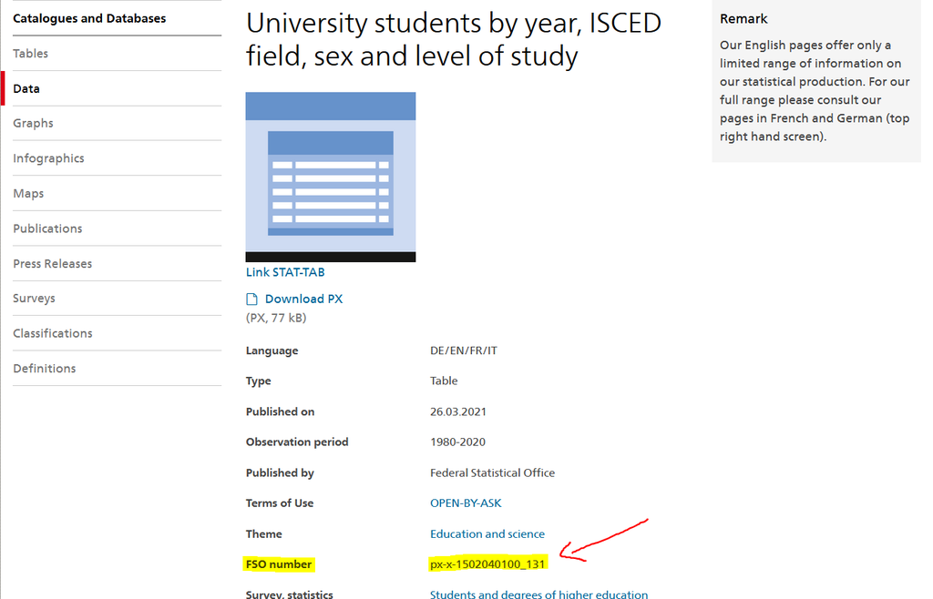

## All you need is `bfs_get_data()`

- Better reproducibility (and stability) with `number_bfs`.

```r
BFS::bfs_get_data(
  number_bfs = "px-x-1502040100_131",
  language = "en"
)
```

```
# A tibble: 18,060 × 5
   Year    `ISCED Field`   Sex   `Level of study` `University students`
   <chr>   <chr>           <chr> <chr>                            <dbl>
 1 1980/81 Education scie… Male  First universit…                   545
 2 1980/81 Education scie… Male  Bachelor                             0
 3 1980/81 Education scie… Male  Master                               0
 4 1980/81 Education scie… Male  Doctorate                           93
 5 1980/81 Education scie… Male  Further educati…                    13
# ℹ 18,050 more rows
```

## All you need is `bfs_get_data()`

- Change the `language`

```r
BFS::bfs_get_data(
  number_bfs = "px-x-1502040100_131",
  language = "de"
)
```

```
# A tibble: 18,060 × 5
   Jahr    `ISCED Fach`  Geschlecht Studienstufe Studierende an den u…¹
   <chr>   <chr>         <chr>      <chr>                         <dbl>
 1 1980/81 Erziehungswi… Mann       Lizenziat/D…                    545
 2 1980/81 Erziehungswi… Mann       Bachelor                          0
 3 1980/81 Erziehungswi… Mann       Master                            0
 4 1980/81 Erziehungswi… Mann       Doktorat                         93
 5 1980/81 Erziehungswi… Mann       Weiterbildu…                     13
# ℹ 18,050 more rows
# ℹ abbreviated name: ¹`Studierende an den universitären Hochschulen`
```

## All you need is `bfs_get_data()`

- Clean names with `janitor::clean_names()` (snake case)

```r
BFS::bfs_get_data(
  number_bfs = "px-x-1502040100_131",
  language = "de",
  clean_names = TRUE
)
```

```
# A tibble: 18,060 × 5
   jahr    isced_fach    geschlecht studienstufe studierende_an_den_u…¹
   <chr>   <chr>         <chr>      <chr>                         <dbl>
 1 1980/81 Erziehungswi… Mann       Lizenziat/D…                    545
 2 1980/81 Erziehungswi… Mann       Bachelor                          0
 3 1980/81 Erziehungswi… Mann       Master                            0
 4 1980/81 Erziehungswi… Mann       Doktorat                         93
 5 1980/81 Erziehungswi… Mann       Weiterbildu…                     13
# ℹ 18,050 more rows
# ℹ abbreviated name: ¹studierende_an_den_universitaren_hochschulen
```

## All you need is `bfs_get_data()`

- Query specific categories with `query`.

```r
BFS::bfs_get_data(
  number_bfs = "px-x-1502040100_131",
  language = "de",
  clean_names = TRUE,
  query = NULL
)
```

## All you need is `bfs_get_data()`

- Use `bfs_get_metadata()` to get query `code` and `values` categories.

```r
metadata <- BFS::bfs_get_metadata(
  number_bfs = "px-x-1502040100_131",
  language = "de"
)
str(metadata)
```

[output not shown]

## All you need is `bfs_get_data()`

- Manually create BFS query dimensions.

```r
BFS::bfs_get_data(
  number_bfs = "px-x-1502040100_131",
  language = "en",
  query = list(
          "Jahr" = c("40", "41"),
          "ISCED Fach" = c("0"),
          "Geschlecht" = c("*"), # Use "*" to select all
          "Studienstufe" = c("2", "3")
          ))
```

```
# A tibble: 8 × 5
  Year    `ISCED Field`    Sex   `Level of study` `University students`
  <chr>   <chr>            <chr> <chr>                            <dbl>
1 2020/21 Education scien… Male  Master                             151
2 2020/21 Education scien… Male  Doctorate                          121
3 2020/21 Education scien… Fema… Master                             555
4 2020/21 Education scien… Fema… Doctorate                          306
5 2021/22 Education scien… Male  Master                             143
```

## All you need is `bfs_get_data()`

- Query the `code` variables and value types.

```r
BFS::bfs_get_data(
  number_bfs = "px-x-1502040100_131",
  language = "en",
  query = list(
          "Jahr" = c("40", "41"),
          "ISCED Fach" = c("0"),
          "Geschlecht" = c("*"), # Use "*" to select all
          "Studienstufe" = c("2", "3")
          ),
  column_name_type = "code", # "text" by default
  variable_value_type = "code") # "text" by default
```

```
# A tibble: 8 × 5
  Jahr  `ISCED Fach` Geschlecht Studienstufe `University students`
  <chr> <chr>        <chr>      <chr>                        <dbl>
1 40    0            0          2                              151
2 40    0            0          3                              121
3 40    0            1          2                              555
4 40    0            1          3                              306
5 41    0            0          2                              143
```

## All you need is `bfs_get_data()`

- Documentation: www.felixluginbuhl.com/BFS
- Source code: www.github.com/lgnbhl/BFS

```r
# open function documentation in R
?bfs_get_data()
```

## 5. Questions

Thank you for your attention!

https://felixluginbuhl.com/BFS